# Lab 7 Notes

```r
#By julie sherman
library(ellipse)
plot_conf_ellipse <- function(..., col = 1, add = FALSE) {
  if (add) {
    pfunc = lines
  } else {
    pfunc = plot
  }
  pfunc(ellipse(...), type = "l", col = col)
}
```

#### Multiple Regeression and Polynomial Regression

```r
head(mtcars)

#Add more regressors with the +
fit <- lm(mpg~disp+hp, data = mtcars)
summary(fit)
```

Can add indicator variables: takes the values 0 or 1 to indicate presence or absence. Careful with the interpretation.

```r
fit2 <- lm(mpg~disp+hp+am, data = mtcars)
summary(fit2)
```

By adding an extra variable, it changed the significance of others. Reasons: -Omitted Variable bias -Multi-colinearity -irrelevance

We want to assess what is the best model, what predictors should be included

#### INteractions

use the *

```r
fit3 <- lm(mpg~disp+hp+am+cyl*vs, data = mtcars)
summary(fit3)
```

If we want literal multiplication, use I()

```r
fitmult <- lm(mpg~disp+hp+am+I(cyl*vs), data= mtcars)
summary(fitmult)
```

```r
fit4 <- lm(mpg~disp+hp+am+as.factor(cyl), data = mtcars)
summary(fit4)
```

#### Inference and Model Selection

##### F-Test:

Tests if the ‘extra’ coefficients are zero

```r
anova(fit, fit4)
```

[output not shown]

Added a significant variable, but is the model really better?

##### Confidence Intervals:

ellipsoids - look at two at a time

```r
vcov(fit4)
```

##### AIC

Which model is best? Consider: -Fit -> how well does it explain the data? Have looked at R^2 previously -Number of predictors. Have looked at adjusted R^2 previously

AIC is basically a better adjusted R^2

Big Idea: Lower AIC score is better Numbers dont really mean anything, depends on model

```r
AIC(fit4)
```

```
[1] 160.6189
```

See notes for finding model with lowest AIC

AIC is an asymptotic method - works best with large samples Don’t just fit models mindlessly and choose the one with lowest AIC

#### Polynomial Regression

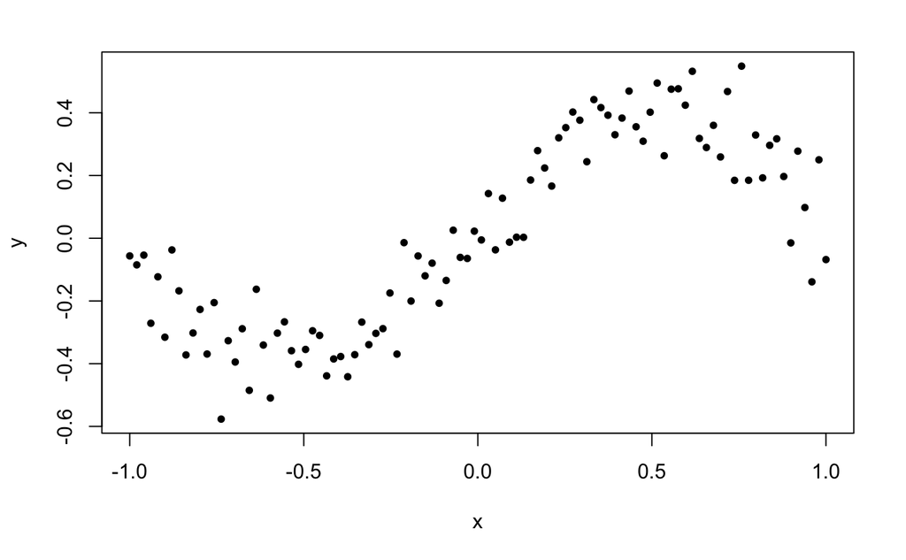

```r
#Making our data
x <- seq(-1,1, length = 100)
y <- x - x^3 + rnorm(100, sd = 0.1)
plot(x,y,pch=20)
```

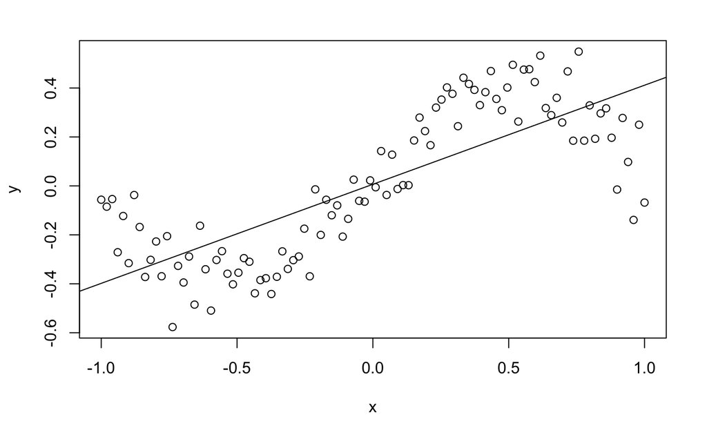

```r
fit <- lm(y~x)
plot(y~x)
abline(fit)
```

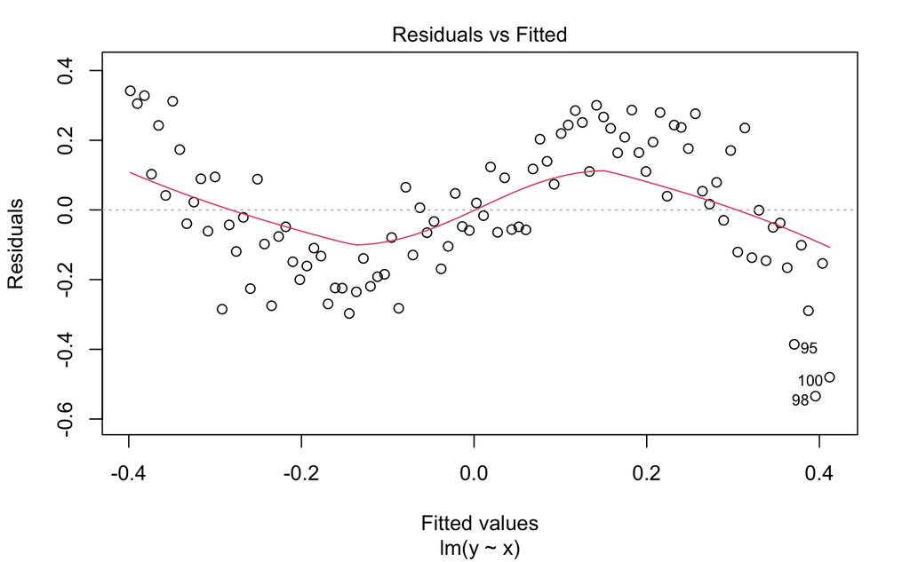

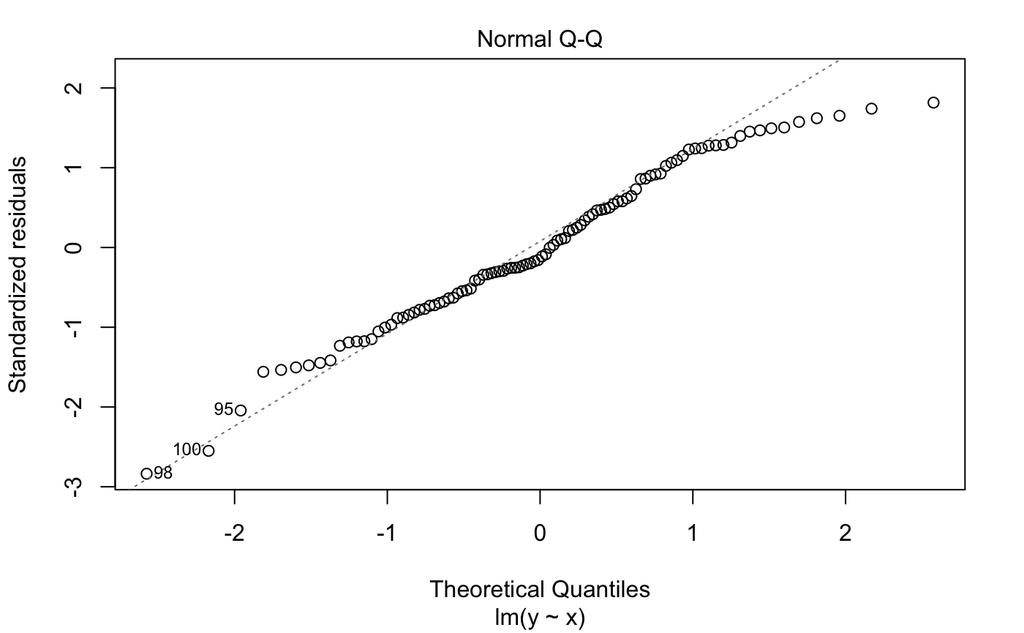

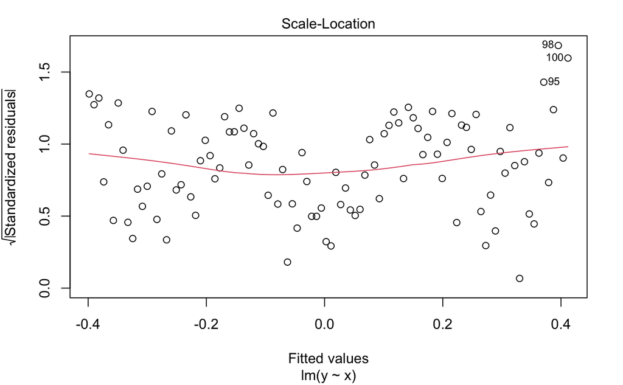

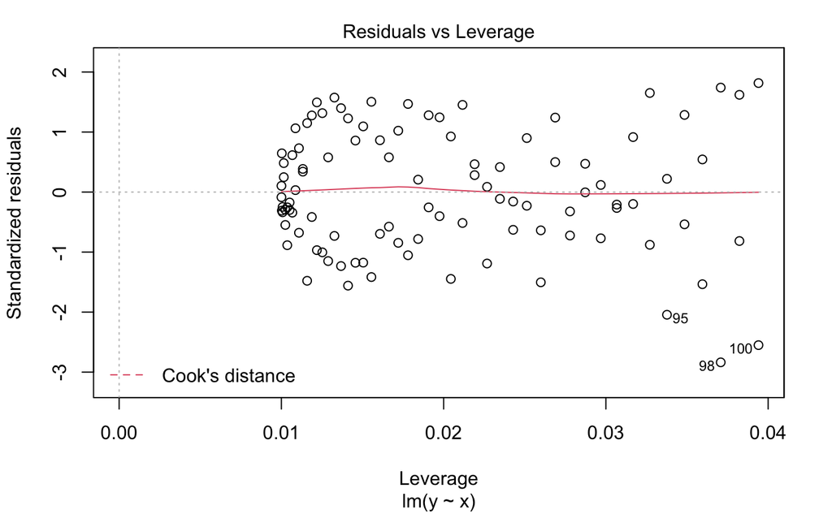

```r
plot(fit)
```

pretty bad results if we just use a linear model

```r
#by julie sherman
predict_func <- function(fit) {
  response <- names(fit$model)[[1]]
  explanatory <- names(fit$model)[[2]]
  function(x, ...) {
    dat <- data.frame(x)
    names(dat) <- explanatory
    predict(fit, dat, ...)
  }
}
```

```r
predict_fit2 <- predict_func(fit2)
lines(x, predict_fit2)
```

[output not shown]